# EEET2574 | Big Data for Engineering

## Assignment 2: MongoDB and Spark

- **Author**: Tran Manh Cuong - s3974735
- **Instructor**: Dr. Arthur Tang

# Task 0: Instruction on how to run the notebook

## Step 1: Create a compute cluster:

- On the sidebar, select **Compute**.
- Select **Create compute**.
- Enter compute name: **Big Data Assignment 2's Cluster**.
- Choose the databricks runtime version: **9.1 LTS ML (Scala 2.12, Spark 3.1.2)**.
- Select **Create compute**.

[figure not shown]

## Step 2: Install mongodb spark connector library

- On the navigation bar, select **Libraries**.
- Select **Install new**.
- For Library Source, select **Maven**.
- For Coordinates, select **Select Packages**.
- Select **Spark Packages**.
- Search and select **mongo-spark** with version **3.0.1**.
- Select **Install**.

[figure not shown]

## Step 3: Attach cluster to notebook

- Import the notebook to databricks using .dbc or .ipynb file.
- Select the notebook.
- For the Connect, select the created cluster.

[figure not shown]

# Task 1: MongoDB

## Load Datasets to MongoDB Collections

The datasets had already been loaded into MongoDB, so you don’t need to run this code.

```python
import pymongo
import pandas as pd
import os

# You can replace the data directory with your own path
ELECTRICITY_DIR = "./data/Electricity"
GAS_DIR = "./data/Gas"

# You can replace the URI with your own MongoDB URI
MONGO_URI = "mongodb+srv://cuongtran:cuongtran123@cluster0.5zjcy.mongodb.net/?retryWrites=true&w=majority&appName=Cluster0"

# MongoDB connection
client = pymongo.MongoClient(MONGO_URI)
db = client["main"]


# Data mapping for collections
collections_mapping = {
    "electricity": {
        "2018": ["coteq_electricity_2018.csv", "stedin_electricity_2018.csv", "westland-infra_electricity_2018.csv"],
        "2019": ["coteq_electricity_2019.csv", "stedin_electricity_2019.csv", "westland-infra_electricity_2019.csv"],
        "2020": ["coteq_electricity_2020.csv", "stedin_electricity_2020.csv", "westland-infra_electricity_2020.csv"]
    },
    "gas": {
        "2018": ["coteq_gas_2018.csv", "stedin_gas_2018.csv", "westland-infra_gas_2018.csv"],
        "2019": ["coteq_gas_2019.csv", "stedin_gas_2019.csv", "westland-infra_gas_2019.csv"],
        "2020": ["coteq_gas_2020.csv", "stedin_gas_2020.csv", "westland-infra_gas_2020.csv"]
    }
}

# Check if a collection exists in MongoDB
def is_collection_exist(collection_name):
    return collection_name in db.list_collection_names()

# Load data into MongoDB
def load_data_to_mongodb(database, directory, year, file_list):
    collection_name = f"{database}_{year}"
    if is_collection_exist(collection_name):
        print(f"Collection {collection_name} already exists. Skipping data load process.")
        return

    collection = db[collection_name]
    for file_name in file_list:
        file_path = os.path.join(directory, file_name)
        df = pd.read_csv(file_path)
        records = df.to_dict(orient="records")
        collection.insert_many(records)
        print(f"Data from {file_name} has been loaded to collection {collection_name}.")

# Main function
def main():
    for database, years in collections_mapping.items():
        for year, file_list in years.items():
            if database == "electricity":
                load_data_to_mongodb(database, ELECTRICITY_DIR, year, file_list)
            elif database == "gas":
                load_data_to_mongodb(database, GAS_DIR, year, file_list)

if __name__ == "__main__":
    main()
```

## Question 1A: How many collections do you have? Why?

The MongoDB database contains a total of 6 collections, categorized based on type of data (Electricity, Gas) and year (2018, 2019, 2020):

- Electricity collections: electricity_2018, electricity_2019, electricity_2020
- Gas collections: gas_2018, gas_2019, gas_2020

This design choice allows targeted querying and manipulation during data ingestion and cleaning in Task 2. By having distinct collections for each category and year, we can streamline the transformation pipeline, as each collection can be processed individually or combined as needed. Furthermore, this structure supports scalable data management. If new data for additional years or companies becomes available, it can easily be incorporated into separate collections without affecting the existing ones.

Another reason for this design is to simplify model training and tracking in Task 3. Since the task requires using 2018 and 2019 data for training and 2020 for testing, the separate collections make it straightforward to load and partition data for machine learning pipelines. Additionally, visualizations in Task 4 benefit from this schema as it allows flexibility to aggregate data across years or focus on specific time frames and data types.

[figure not shown]

# Task 2: Data ingestion and data cleaning/transformation

## Data Ingestion

Load electricity and gas consumption data from MongoDB into PySpark DataFrames

```python
from pyspark.sql import SparkSession

# MongoDB URI
MONGO_URI = "mongodb+srv://cuongtran:cuongtran123@cluster0.5zjcy.mongodb.net/?retryWrites=true&w=majority&appName=Cluster0"

# Initialize Spark session
spark = SparkSession.builder \
    .appName("Big_Data_ASM2") \
    .config("spark.mongodb.input.uri", MONGO_URI) \
    .config("spark.mongodb.output.uri", MONGO_URI) \
    .getOrCreate()

# Electricity collections
electricity_2018_df = spark.read.format("com.mongodb.spark.sql.DefaultSource") \
    .option("uri", MONGO_URI) \
    .option("database", "main") \
    .option("collection", "electricity_2018") \
    .load()

electricity_2019_df = spark.read.format("com.mongodb.spark.sql.DefaultSource") \
    .option("uri", MONGO_URI) \
    .option("database", "main") \
    .option("collection", "electricity_2019") \
    .load()

electricity_2020_df = spark.read.format("com.mongodb.spark.sql.DefaultSource") \
    .option("uri", MONGO_URI) \
    .option("database", "main") \
    .option("collection", "electricity_2020") \
    .load()

# Gas collections
gas_2018_df = spark.read.format("com.mongodb.spark.sql.DefaultSource") \
    .option("uri", MONGO_URI) \
    .option("database", "main") \
    .option("collection", "gas_2018") \
    .load()

gas_2019_df = spark.read.format("com.mongodb.spark.sql.DefaultSource") \
    .option("uri", MONGO_URI) \
    .option("database", "main") \
    .option("collection", "gas_2019") \
    .load()

gas_2020_df = spark.read.format("com.mongodb.spark.sql.DefaultSource") \
    .option("uri", MONGO_URI) \
    .option("database", "main") \
    .option("collection", "gas_2020") \
    .load()
```

Concatenate the 2018 and 2019 dataframes to create train datasets and assigns the 2020 dataframes as test datasets for Task 3.

```python
# Train datasets
electricity_train_df = electricity_2018_df.union(electricity_2019_df)
gas_train_df = gas_2018_df.union(gas_2019_df)

# Test datasets
electricity_test_df = electricity_2020_df
gas_test_df = gas_2020_df
```

## Data Exploration

Convert the Spark DataFrames for electricity and gas train datasets into Pandas DataFrames using the `toPandas()` method. The purpose of this conversion is to facilitate data exploration using Pandas' versatile and intuitive tools, which are better suited for detailed analysis, such as summarizing data, checking for missing values, and visualizing distributions

```python
electricity_pandas_df = electricity_train_df.toPandas()
gas_pandas_df = gas_train_df.toPandas()
```

Display the number of rows and columns to understand the overall size of the dataset.

```python
electricity_pandas_df.shape
```

```
Out[69]: (176807, 16)
```

```python
gas_pandas_df.shape
```

```
Out[70]: (187606, 16)
```

Preview the first five rows of the electricity and gas train datasets to understand the structure, column names, and sample data.

```python
electricity_pandas_df.head()
```

|  | %Defintieve aansl (NRM) | _id | annual_consume | annual_consume_lowtarif_perc | city | delivery_perc | net_manager | num_connections | perc_of_active_connections | purchase_area | smartmeter_perc | street | type_conn_perc | type_of_connection | zipcode_from | zipcode_to |
| --- | --- | --- | --- | --- | --- | --- | --- | --- | --- | --- | --- | --- | --- | --- | --- | --- |
| 0 | NaN | {'oid': '676d0e00999375116ce42b08'} | 4122 | 89.47 | ENTER | 89.47 | Coteq Netbeheer BV | 19 | 94.74 | Netbeheerder Centraal Overijssel B.V. | 0.0 | Dorpsstraat | 89.0 | 1x35 | 7468CP | 7471AA |
| 1 | NaN | {'oid': '676d0e00999375116ce42b09'} | 1800 | 94.59 | GOOR | 100.00 | Coteq Netbeheer BV | 37 | 100.00 | Netbeheerder Centraal Overijssel B.V. | 0.0 | De Stoevelaar | 86.0 | 1x35 | 7471AB | 7471AB |
| 2 | NaN | {'oid': '676d0e00999375116ce42b0a'} | 1315 | 100.00 | GOOR | 100.00 | Coteq Netbeheer BV | 16 | 100.00 | Netbeheerder Centraal Overijssel B.V. | 0.0 | De Stoevelaar | 100.0 | 1x35 | 7471AC | 7471AC |
| 3 | NaN | {'oid': '676d0e00999375116ce42b0b'} | 6379 | 92.00 | GOOR | 92.00 | Coteq Netbeheer BV | 25 | 84.00 | Netbeheerder Centraal Overijssel B.V. | 0.0 | De Stoevelaar | 44.0 | 1x35 | 7471AD | 7471AE |
| 4 | NaN | {'oid': '676d0e00999375116ce42b0c'} | 4404 | 92.86 | GOOR | 85.71 | Coteq Netbeheer BV | 14 | 100.00 | Netbeheerder Centraal Overijssel B.V. | 0.0 | Kerkstraat | 36.0 | 1x35 | 7471AG | 7471AG |

```python
gas_pandas_df.head()
```

|  | %Defintieve aansl (NRM) | _id | annual_consume | annual_consume_lowtarif_perc | city | delivery_perc | net_manager | num_connections | perc_of_active_connections | purchase_area | smartmeter_perc | street | type_conn_perc | type_of_connection | zipcode_from | zipcode_to |
| --- | --- | --- | --- | --- | --- | --- | --- | --- | --- | --- | --- | --- | --- | --- | --- | --- |
| 0 | NaN | {'oid': '676d0e57999375116ce842fd'} | 3457 | 0.0 | HAAFTEN | 100.0 | Coteq Netbeheer BV | 18 | 83.33 | GAS Gastransport Services (GASUNIE) | 0.0 | Margrietstraat | 78.0 | G4 | 4175GA | 7165BD |
| 1 | NaN | {'oid': '676d0e57999375116ce842fe'} | 4036 | 0.0 | RIETMOLEN | 100.0 | Coteq Netbeheer BV | 17 | 100.00 | GAS Gastransport Services (GASUNIE) | 0.0 | Oude Deldenseweg | 76.0 | G4 | 7165BG | 7216PN |
| 2 | NaN | {'oid': '676d0e57999375116ce842ff'} | 3695 | 0.0 | KRING VAN DORTH | 100.0 | Coteq Netbeheer BV | 117 | 100.00 | GAS Gastransport Services (GASUNIE) | 0.0 | Wippertdijk | 71.0 | G4 | 7216PP | 7245TG |
| 3 | NaN | {'oid': '676d0e57999375116ce84300'} | 3307 | 0.0 | LAREN GLD | 100.0 | Coteq Netbeheer BV | 26 | 100.00 | GAS Gastransport Services (GASUNIE) | 0.0 | Warfveendijk | 62.0 | G4 | 7245TH | 7245TP |
| 4 | NaN | {'oid': '676d0e57999375116ce84301'} | 2306 | 0.0 | LAREN GLD | 100.0 | Coteq Netbeheer BV | 81 | 97.53 | GAS Gastransport Services (GASUNIE) | 0.0 | Kielersdijk | 78.0 | G4 | 7245TS | 7275AZ |

Display the data types of each column to understand which features are numerical, categorical, or require further transformation. The result indicates that most numerical columns are suitable for scaling, while categorical columns will need encoding during the data transformation process.

```python
electricity_pandas_df.dtypes
```

```
Out[12]: %Defintieve aansl (NRM)         float64
_id                              object
annual_consume                    int32
annual_consume_lowtarif_perc    float64
city                             object
delivery_perc                   float64
net_manager                      object
num_connections                   int32
perc_of_active_connections      float64
purchase_area                    object
smartmeter_perc                 float64
street                           object
type_conn_perc                  float64
type_of_connection               object
zipcode_from                     object
zipcode_to                       object
dtype: object
```

```python
gas_pandas_df.dtypes
```

```
Out[13]: %Defintieve aansl (NRM)         float64
_id                              object
annual_consume                    int32
annual_consume_lowtarif_perc    float64
city                             object
delivery_perc                   float64
net_manager                      object
num_connections                   int32
perc_of_active_connections      float64
purchase_area                    object
smartmeter_perc                 float64
street                           object
type_conn_perc                  float64
type_of_connection               object
zipcode_from                     object
zipcode_to                       object
dtype: object
```

Check for missing values in each column to identify potential data quality issues. The results reveal that the **%Defintieve aansl (NRM)** column has a significant number of missing values (171,965 in electricity and 182,994 in gas datasets), indicating it may require removal or imputation. All other columns have no missing values, suggesting they are ready for further analysis and transformation.

```python
electricity_pandas_df.isnull().sum()
```

```
Out[47]: %Defintieve aansl (NRM)         171965
_id                                  0
annual_consume                       0
annual_consume_lowtarif_perc         0
city                                 0
delivery_perc                        0
net_manager                          0
num_connections                      0
perc_of_active_connections           0
purchase_area                        0
smartmeter_perc                      0
street                               0
type_conn_perc                       0
type_of_connection                   0
zipcode_from                         0
zipcode_to                           0
dtype: int64
```

```python
gas_pandas_df.isnull().sum()
```

```
Out[15]: %Defintieve aansl (NRM)         182994
_id                                  0
annual_consume                       0
annual_consume_lowtarif_perc         0
city                                 0
delivery_perc                        0
net_manager                          0
num_connections                      0
perc_of_active_connections           0
purchase_area                        0
smartmeter_perc                      0
street                               0
type_conn_perc                       0
type_of_connection                   0
zipcode_from                         0
zipcode_to                           0
dtype: int64
```

Identify and categorize columns into numerical and categorical features for targeted exploration and transformation.

```python
numerical_columns = [
    "annual_consume",
    "annual_consume_lowtarif_perc",
    "delivery_perc",
    "num_connections",
    "perc_of_active_connections",
    "smartmeter_perc",
    "type_conn_perc"
]

categorical_columns = [
    "city",
    "net_manager",
    "purchase_area",
    "street",
    "type_of_connection",
    "zipcode_from",
    "zipcode_to"
]
```

Generate summary statistics for numerical columns to understand their distribution, central tendency, and spread. The electricity dataset shows notable outliers in **annual_consume** (max 110,857 vs. mean 3,913) and **num_connections** (max 1,146 vs. mean 25), indicating skewness that may require log transformation. Similarly, the gas dataset reveals significant skewness in **annual_consume** (max 27,917 vs. mean 1,559) and **num_connections** (max 1,065 vs. mean 22). These findings highlight the need for outlier handling, scaling, and possible transformation during the data cleaning and transformation phases. Additionally, the constant value in **annual_consume_lowtarif_perc** for gas indicates it may not provide significant variability for modeling.

```python
electricity_pandas_df[numerical_columns].describe()
```

|  | annual_consume | annual_consume_lowtarif_perc | delivery_perc | num_connections | perc_of_active_connections | smartmeter_perc | type_conn_perc |
| --- | --- | --- | --- | --- | --- | --- | --- |
| count | 176807.000000 | 176807.000000 | 176807.000000 | 176807.000000 | 176807.000000 | 176807.000000 | 176807.000000 |
| mean | 3913.422755 | 87.088556 | 94.702266 | 25.088967 | 98.100261 | 51.591278 | 79.550555 |
| std | 3281.350003 | 18.725204 | 10.108968 | 18.562825 | 8.291340 | 32.459691 | 18.855133 |
| min | 0.000000 | 0.000000 | 0.000000 | 10.000000 | 0.000000 | 0.000000 | 18.000000 |
| 25% | 2387.000000 | 81.480000 | 92.860000 | 16.000000 | 100.000000 | 20.000000 | 65.000000 |
| 50% | 3114.000000 | 95.240000 | 100.000000 | 21.000000 | 100.000000 | 57.140000 | 86.000000 |
| 75% | 4055.000000 | 100.000000 | 100.000000 | 28.000000 | 100.000000 | 80.950000 | 96.000000 |
| max | 110857.000000 | 100.000000 | 100.000000 | 1146.000000 | 100.000000 | 100.000000 | 100.000000 |

```python
gas_pandas_df[numerical_columns].describe()
```

|  | annual_consume | annual_consume_lowtarif_perc | delivery_perc | num_connections | perc_of_active_connections | smartmeter_perc | type_conn_perc |
| --- | --- | --- | --- | --- | --- | --- | --- |
| count | 187606.000000 | 187606.0 | 187606.000000 | 187606.000000 | 187606.000000 | 187606.000000 | 187606.000000 |
| mean | 1559.704295 | 0.0 | 99.999916 | 22.961163 | 98.481916 | 44.454565 | 92.566943 |
| std | 959.909904 | 0.0 | 0.022761 | 14.325173 | 7.398859 | 33.689301 | 12.169933 |
| min | 0.000000 | 0.0 | 90.910000 | 10.000000 | 0.000000 | 0.000000 | 21.000000 |
| 25% | 1065.000000 | 0.0 | 100.000000 | 15.000000 | 100.000000 | 12.500000 | 90.000000 |
| 50% | 1374.000000 | 0.0 | 100.000000 | 20.000000 | 100.000000 | 40.000000 | 100.000000 |
| 75% | 1825.000000 | 0.0 | 100.000000 | 26.000000 | 100.000000 | 76.920000 | 100.000000 |
| max | 27917.000000 | 0.0 | 100.000000 | 1065.000000 | 100.000000 | 100.000000 | 100.000000 |

Analyze the unique value counts for categorical columns to understand their diversity and identify potential encoding challenges. Both datasets have a high cardinality in **street**, **zipcode_from**, and **zipcode_to**, which may require dimensionality reduction or exclusion if they do not provide meaningful insights. Columns like **net_manager**, **purchase_area**, and **type_of_connection** have relatively fewer unique values, making them suitable for encoding during the transformation process.

```python
electricity_pandas_df[categorical_columns].nunique()
```

```
Out[19]: city                    287
net_manager              10
purchase_area             9
street                29426
type_of_connection       10
zipcode_from          89513
zipcode_to            88945
dtype: int64
```

```python
gas_pandas_df[categorical_columns].nunique()
```

```
Out[20]: city                    491
net_manager              14
purchase_area            39
street                31598
type_of_connection        6
zipcode_from          95617
zipcode_to            95087
dtype: int64
```

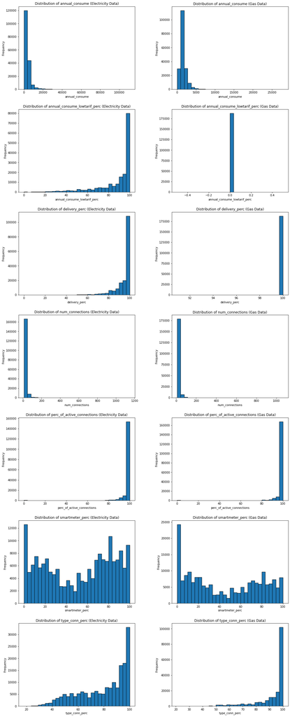

```python
import matplotlib.pyplot as plt

fig, axes = plt.subplots(len(numerical_columns), 2, figsize=(14, 5 * len(numerical_columns)))
fig.tight_layout(w_pad=10.0, h_pad=5.0)

for i, col in enumerate(numerical_columns):
    # Electricity histogram
    axes[i, 0].hist(electricity_pandas_df[col], bins=30, edgecolor='black')
    axes[i, 0].set_title(f"Distribution of {col} (Electricity Data)")
    axes[i, 0].set_xlabel(col)
    axes[i, 0].set_ylabel("Frequency")

    # Gas histogram
    axes[i, 1].hist(gas_pandas_df[col], bins=30, edgecolor='black')
    axes[i, 1].set_title(f"Distribution of {col} (Gas Data)")
    axes[i, 1].set_xlabel(col)
    axes[i, 1].set_ylabel("Frequency")

plt.show()
```

Analyze the frequency distributions of key categorical columns to understand the diversity and dominance of specific categories. In the **city** column, both electricity and gas datasets have a significant number of unique values, indicating a high geographical coverage. The **net_manager** and **purchase_area** columns show skewed distributions, with a few dominant categories, such as **8716892000005** for **net_manager** and **Stedin** for **purchase_area**. Similarly, **type_of_connection** is dominated by **1x35** in electricity and **G4** in gas, indicating standardized types of connections.

```python
electricity_pandas_df["city"].value_counts()
```

```
Out[22]: 'S-GRAVENHAGE      23069
ROTTERDAM          20644
UTRECHT            11949
AMERSFOORT          5182
ZOETERMEER          5038
                   ...
NIEUWGEIN              1
ZEVENHOVEN             1
'SâGRAVENHAGE        1
MAURIK                 1
AMSTELVEEN             1
Name: city, Length: 287, dtype: int64
```

```python
gas_pandas_df["city"].value_counts()
```

```
Out[23]: 'S-GRAVENHAGE          20702
ROTTERDAM              17994
UTRECHT                 9712
AMERSFOORT              4792
ZOETERMEER              4107
                       ...
ZWAAGWESTEINDE             1
DAMWOUDE                   1
NEDERHORST DEN BERG        1
'S GRAVENDEEL              1
NIGTEVECHT                 1
Name: city, Length: 491, dtype: int64
```

```python
electricity_pandas_df["net_manager"].value_counts()
```

```
Out[24]: 8716892000005              89266
8716874000009              51435
8716886000004              13073
8716921000006               8628
westland-infra              4842
8716925000002               3150
Cogas Infra & Beheer BV     2563
Coteq Netbeheer BV          2503
8716946000005               1331
8716924000003                 16
Name: net_manager, dtype: int64
```

```python
gas_pandas_df["net_manager"].value_counts()
```

```
Out[25]: 8716892000005              81232
8716874000009              39433
8716886000004              11291
8716921000006               8015
Cogas Infra & Beheer BV     6868
Coteq Netbeheer BV          6774
8716892700004               6098
8716892750009               6032
8716892740000               5825
8716892710003               5134
westland-infra              4612
8716892720002               3285
8716925000002               3002
8716924000003                  5
Name: net_manager, dtype: int64
```

```python
electricity_pandas_df["purchase_area"].value_counts()
```

```
Out[26]: Stedin                                    88881
Stedin Utrecht                            51669
Stedin Delfland                           13330
Stedin Midden-Holland                      8524
Netbeheerder Centraal Overijssel B.V.      5066
871687800090000015                         4842
Stedin Schiedam                            3149
Stedin Elektriciteit Zuid-Kennemerland     1330
Stedin Weert                                 16
Name: purchase_area, dtype: int64
```

```python
gas_pandas_df["purchase_area"].value_counts()
```

```
Out[27]: NG Den Haag                            26217
Pseudo Gos Houten ENBU                 23313
Pseudo-GOS Dordrecht                   17420
GAS Gastransport Services (GASUNIE)    13642
Pseudo-GOS Rotterdam                   13100
Pseudo Gos Hoogland ENBU                9550
NG Leerdam                              8520
Pseudo-GOS Zoetermeer                   6606
Pseudo Gos Veenendaal ENBU              6602
NG Gouda                                6313
Pseudo-GOS Zeist                        6032
Pseudo-GOS Amstelland                   5580
NG Noord-Oost Friesland                 5551
NG Hoekse waard                         5267
Pseudo-GOS Midden Kennemerland          5134
871718518003006694                      4612
Pseudo-GOS Delft                        3805
NG Heemstede                            3032
Schiedam Kethel                         3002
Pseudo-GOS Vlaardingen                  2624
NG Brielle                              2313
NG Krimpen                              1664
NG Waddinxveen                          1662
Achterweg                               1610
Maassluis                               1077
Pseudo-GOS Bleiswijk                     891
Oranjelaan                               460
Hoek van Holland                         386
Ouderkerk ad Amstel                      366
Ameland                                  272
Halfweg                                  252
Ruigendijk                               228
Moerseweg                                217
Duivendrecht                             153
Graswalseweg                             115
Wildersekade                              12
Pseudo-GOS Weert                           4
NaN                                        1
Weert Trancheeweg                          1
Name: purchase_area, dtype: int64
```

```python
electricity_pandas_df["type_of_connection"].value_counts()
```

```
Out[28]: 1x35    126663
3x25     29887
1x25     14674
1x50      4416
3x35       769
3x63       189
3x80        98
3x50        85
OBK         19
1x6          7
Name: type_of_connection, dtype: int64
```

```python
gas_pandas_df["type_of_connection"].value_counts()
```

```
Out[29]: G4     182367
G6       4243
OBK       677
G16       216
G10        57
G25        46
Name: type_of_connection, dtype: int64
```

Generate correlation heatmaps for numerical columns to identify potential linear relationships between features. The result shows that most features have weak or no correlations.

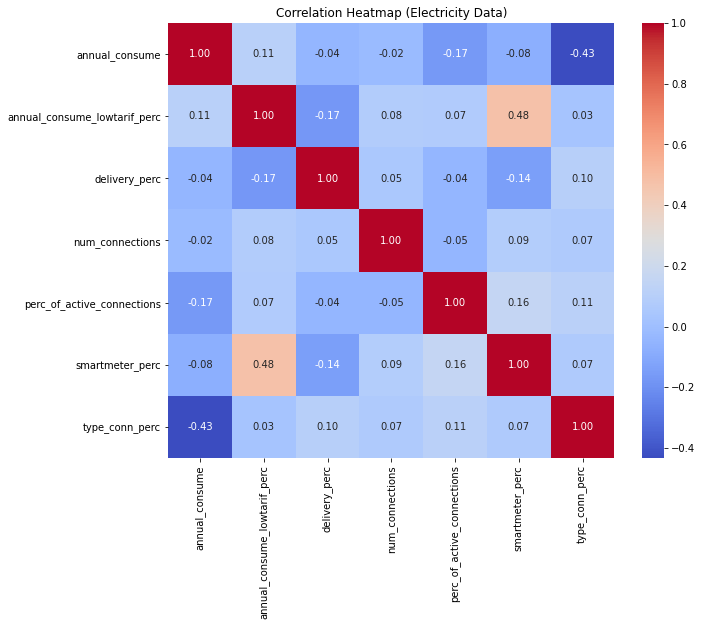

```python
import seaborn as sns

# Heatmap for Electricity Data
plt.figure(figsize=(10, 8))
sns.heatmap(electricity_pandas_df[numerical_columns].corr(), annot=True, fmt=".2f", cmap="coolwarm")
plt.title("Correlation Heatmap (Electricity Data)")
plt.show()
```

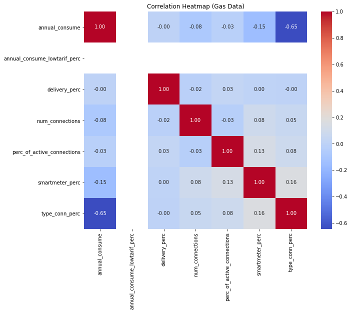

```python
# Heatmap for Gas Data
plt.figure(figsize=(10, 8))
sns.heatmap(gas_pandas_df[numerical_columns].corr(), annot=True, fmt=".2f", cmap="coolwarm")
plt.title("Correlation Heatmap (Gas Data)")
plt.show()
```

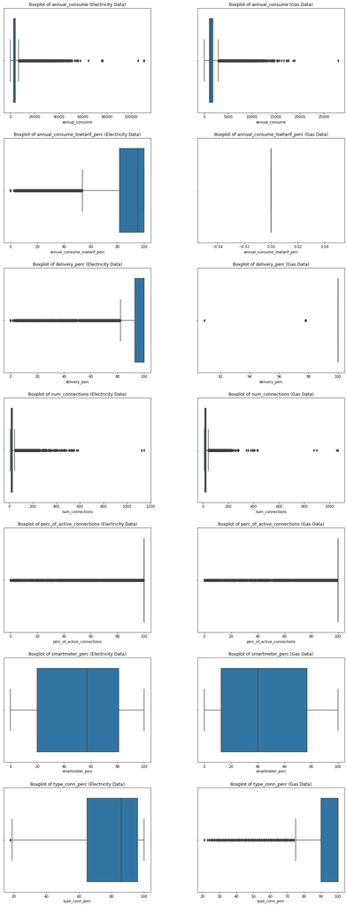

```python
fig, axes = plt.subplots(len(numerical_columns), 2, figsize=(14, 5 * len(numerical_columns)))
fig.tight_layout(w_pad=10.0, h_pad=5.0)

for i, col in enumerate(numerical_columns):
    sns.boxplot(x=electricity_pandas_df[col], ax=axes[i, 0])
    axes[i, 0].set_title(f"Boxplot of {col} (Electricity Data)")
    axes[i, 0].set_xlabel(col)

    sns.boxplot(x=gas_pandas_df[col], ax=axes[i, 1])
    axes[i, 1].set_title(f"Boxplot of {col} (Gas Data)")
    axes[i, 1].set_xlabel(col)

plt.show()
```

## Question 2A: What are the chosen data cleaning steps? Why?

### Step 1: Drop Columns with Missing Values

The **%Defintieve aansl (NRM)** column has an overwhelming number of missing values (171,965 in the electricity dataset and 182,994 in the gas dataset), accounting for the majority of rows. Imputation for such a large percentage of missing values would be impractical and unreliable, while retaining the column may introduce noise to the analysis. Since it does not provide meaningful information for modeling, this column is dropped entirely from all datasets.

```python
electricity_train_df = electricity_train_df.drop("%Defintieve aansl (NRM)")
gas_train_df = gas_train_df.drop("%Defintieve aansl (NRM)")
electricity_test_df = electricity_test_df.drop("%Defintieve aansl (NRM)")
gas_test_df = gas_test_df.drop("%Defintieve aansl (NRM)")
```

### Step 2: Drop Columns with Low Analytical Values

Columns such as **_id**, **street**, **zipcode_from**, and **zipcode_to** are identifiers or high-cardinality features that do not provide meaningful patterns for analysis. Encoding them would lead to sparse datasets, adding computational overhead without improving model accuracy. These columns are removed to focus on features with higher analytical value.

```python
columns_to_drop = ["_id", "street", "zipcode_from", "zipcode_to"]

electricity_train_df = electricity_train_df.drop(*columns_to_drop)
gas_train_df = gas_train_df.drop(*columns_to_drop)
electricity_test_df = electricity_test_df.drop(*columns_to_drop)
gas_test_df = gas_test_df.drop(*columns_to_drop)
```

### Step 3: Drop Columns with Constant Values

The **annual_consume_lowtarif_perc** column in the gas dataset contains a constant value of 0 across all rows, offering no variability or predictive power for the model. Retaining this column would introduce redundancy without contributing to the model’s performance. Thus, this column is removed to simplify the dataset and improve efficiency.

```python
gas_train_df = gas_train_df.drop("annual_consume_lowtarif_perc")
gas_test_df = gas_test_df.drop("annual_consume_lowtarif_perc")
```

### Step 4: Handle Outliers in Numerical Columns

```python
from pyspark.sql.functions import log1p

columns_to_transform = ["annual_consume", "num_connections", "type_conn_perc"]
for col in columns_to_transform:
    electricity_train_df = electricity_train_df.withColumn(col, log1p(electricity_train_df[col]))
    gas_train_df = gas_train_df.withColumn(col, log1p(gas_train_df[col]))
    electricity_test_df = electricity_test_df.withColumn(col, log1p(electricity_test_df[col]))
    gas_test_df = gas_test_df.withColumn(col, log1p(gas_test_df[col]))
```

### Step 5: Verify Data Integrity

After cleaning, it is essential to ensure data integrity by checking for duplicate rows, missing values, or anomalies in the datasets. Duplicate rows are removed to prevent biases during modeling, and missing value checks confirm that no additional imputation or removal is required. This step ensures the datasets are fully prepared for transformation and analysis.

```python
# Remove duplicates
electricity_train_df = electricity_train_df.dropDuplicates()
gas_train_df = gas_train_df.dropDuplicates()
electricity_test_df = electricity_test_df.dropDuplicates()
gas_test_df = gas_test_df.dropDuplicates()
```

```python
from pyspark.sql.functions import col, sum as _sum

# Verify missing values
display(electricity_train_df.select([_sum(col(c).isNull().cast("int")).alias(c) for c in electricity_train_df.columns]))
```

| annual_consume | annual_consume_lowtarif_perc | city | delivery_perc | net_manager | num_connections | perc_of_active_connections | purchase_area | smartmeter_perc | type_conn_perc | type_of_connection |
| --- | --- | --- | --- | --- | --- | --- | --- | --- | --- | --- |
| 0 | 0 | 0 | 0 | 0 | 0 | 0 | 0 | 0 | 0 | 0 |

```python
display(gas_train_df.select([_sum(col(c).isNull().cast("int")).alias(c) for c in gas_train_df.columns]))
```

| annual_consume | city | delivery_perc | net_manager | num_connections | perc_of_active_connections | purchase_area | smartmeter_perc | type_conn_perc | type_of_connection |
| --- | --- | --- | --- | --- | --- | --- | --- | --- | --- |
| 0 | 0 | 0 | 0 | 0 | 0 | 0 | 0 | 0 | 0 |

## Question 2B: What are the chosen data transformation steps? Why?

### Step 1: Encode Categorical Variables

Categorical variables, such as **city**, **net_manager**, **purchase_area**, and **type_of_connection**, are non-numeric and cannot be directly used by most machine learning algorithms. Using `StringIndexer`, each category is assigned a unique numerical index, capturing categorical distinctions. To avoid introducing ordinal bias (where numerical values imply ranking), these indices are converted into binary vectors using `OneHotEncoder`. This step ensures that all categorical variables are represented in a way that preserves their relationships without misinterpreting their values as numeric magnitudes.

```python
from pyspark.ml.feature import StringIndexer, OneHotEncoder

categorical_columns = ["city", "net_manager", "purchase_area", "type_of_connection"]

# String Indexing and One-Hot Encoding for each categorical column
indexers = [StringIndexer(inputCol=col, outputCol=f"{col}_index", handleInvalid="keep") for col in categorical_columns]
encoders = [OneHotEncoder(inputCol=f"{col}_index", outputCol=f"{col}_onehot") for col in categorical_columns]

# Combine all transformations into a list
categorical_transformations = indexers + encoders
```

### Step 2: Scale Numerical Features

```python
from pyspark.ml.feature import MinMaxScaler, VectorAssembler

numerical_columns = ["num_connections", "type_conn_perc"]

# Assemble numerical columns into a single vector for scaling
assembler = VectorAssembler(inputCols=numerical_columns, outputCol="numerical_features")
scaler = MinMaxScaler(inputCol="numerical_features", outputCol="scaled_numerical_features")

# Combine assembler and scaler into a list
numerical_transformations = [assembler, scaler]
```

### Step 3: Assemble Features

Machine learning models typically require a single vector column containing all the features. After encoding categorical variables and scaling numerical features, the `VectorAssembler` consolidates all transformed columns (scaled_numerical_features and one-hot encoded categorical columns) into a unified features column. This step ensures that the data is structured consistently and efficiently for input into machine learning pipelines.

```python
all_features = [f"{col}_onehot" for col in categorical_columns] + ["scaled_numerical_features"]

# Assemble all features into a single vector
feature_assembler = VectorAssembler(inputCols=all_features, outputCol="features")
```

# Task 3: Model training and tracking with data pipeline and MLflow

## Data Preparation

```python
# Target column
target_column = "annual_consume"

# Prepare datasets with labeled target column
electricity_train_df = electricity_train_df.withColumnRenamed(target_column, "label")
electricity_test_df = electricity_test_df.withColumnRenamed(target_column, "label")
gas_train_df = gas_train_df.withColumnRenamed(target_column, "label")
gas_test_df = gas_test_df.withColumnRenamed(target_column, "label")
```

## Define Reusable Training and Logging Pipeline

```python
from pyspark.ml import Pipeline
from pyspark.ml.regression import RandomForestRegressor, DecisionTreeRegressor, GBTRegressor
from pyspark.ml.evaluation import RegressionEvaluator
from pyspark.sql.functions import col
import mlflow
import mlflow.spark

def train_and_log_model(train_data, test_data, algorithm, params):
    with mlflow.start_run():
        # Initialize the model
        if algorithm == "RandomForestRegressor":
            model = RandomForestRegressor(featuresCol="features", labelCol="label", **params)
        elif algorithm == "DecisionTreeRegressor":
            model = DecisionTreeRegressor(featuresCol="features", labelCol="label", **params)

        # Create pipeline
        pipeline = Pipeline(stages=categorical_transformations + numerical_transformations + [feature_assembler] + [model])

        # Train the model
        trained_pipeline = pipeline.fit(train_data)

        # Predict on test data
        predictions = trained_pipeline.transform(test_data)

        # Evaluate the model
        evaluator_mae = RegressionEvaluator(labelCol="label", predictionCol="prediction", metricName="mae")
        evaluator_r2 = RegressionEvaluator(labelCol="label", predictionCol="prediction", metricName="r2")
        evaluator_rmse = RegressionEvaluator(labelCol="label", predictionCol="prediction", metricName="rmse")

        mae = evaluator_mae.evaluate(predictions)
        r2 = evaluator_r2.evaluate(predictions)
        rmse = evaluator_rmse.evaluate(predictions)

        # Log parameters, metrics, and the model
        mlflow.log_param("algorithm", algorithm)
        mlflow.log_params(params)
        mlflow.log_metric("MAE", mae)
        mlflow.log_metric("R2", r2)
        mlflow.log_metric("RMSE", rmse)
        mlflow.spark.log_model(trained_pipeline, "model")

        print(f"Logged {algorithm} with params {params}")
        print("Evaluation metrics:")
        print(f"- MAE: {mae}")
        print(f"- R2: {r2}")
        print(f"- RMSE: {rmse}")
```

## Define Different Parameter Settings for Each Algorithm.

```python
# Random Forest parameters
random_forest_params = [
    {"numTrees": 10, "maxDepth": 3},  # Small number of trees, shallow depth
    {"numTrees": 20, "maxDepth": 5},  # Slightly deeper with more trees
    {"numTrees": 30, "maxDepth": 7}   # Moderate depth and tree count
]

# Decision Tree parameters
decision_tree_params = [
    {"maxDepth": 3, "minInstancesPerNode": 1},  # Shallow tree
    {"maxDepth": 5, "minInstancesPerNode": 2},  # Slightly deeper
    {"maxDepth": 7, "minInstancesPerNode": 2}   # Moderate depth
]
```

## Electricity Model Training

### Random Forest Regressor Model

```python
train_and_log_model(electricity_train_df, electricity_test_df, "RandomForestRegressor", random_forest_params[0])
```

```
Logged RandomForestRegressor with params {'numTrees': 10, 'maxDepth': 3}
Evaluation metrics:
- MAE: 0.3245205459858661
- R2: 0.3055551751803406
- RMSE: 0.43719801389464497
```

```python
train_and_log_model(electricity_train_df, electricity_test_df, "RandomForestRegressor", random_forest_params[1])
```

```
Logged RandomForestRegressor with params {'numTrees': 20, 'maxDepth': 5}
Evaluation metrics:
- MAE: 0.30309765928996096
- R2: 0.4100154729258382
- RMSE: 0.4029764052916728
```

```python
train_and_log_model(electricity_train_df, electricity_test_df, "RandomForestRegressor", random_forest_params[2])
```

```
Logged RandomForestRegressor with params {'numTrees': 30, 'maxDepth': 7}
Evaluation metrics:
- MAE: 0.2924566271932784
- R2: 0.45467513836524165
- RMSE: 0.38742438864546014
```

### Decision Tree Regressor Model

```python
train_and_log_model(electricity_train_df, electricity_test_df, "DecisionTreeRegressor", decision_tree_params[0])
```

```
Logged DecisionTreeRegressor with params {'maxDepth': 3, 'minInstancesPerNode': 1}
Evaluation metrics:
- MAE: 0.3198013444238246
- R2: 0.33819237191648355
- RMSE: 0.4268007675394118
```

```python
train_and_log_model(electricity_train_df, electricity_test_df, "DecisionTreeRegressor", decision_tree_params[1])
```

```
Logged DecisionTreeRegressor with params {'maxDepth': 5, 'minInstancesPerNode': 2}
Evaluation metrics:
- MAE: 0.3005998752347698
- R2: 0.41813901313332635
- RMSE: 0.40019248323442663
```

```python
train_and_log_model(electricity_train_df, electricity_test_df, "DecisionTreeRegressor", decision_tree_params[2])
```

```
Logged DecisionTreeRegressor with params {'maxDepth': 7, 'minInstancesPerNode': 2}
Evaluation metrics:
- MAE: 0.2919387583533915
- R2: 0.4505358781081866
- RMSE: 0.3888919714346681
```

## Gas Model Training

### Random Forest Regressor Model

```python
train_and_log_model(gas_train_df, gas_test_df, "RandomForestRegressor", random_forest_params[0])
```

```
Logged RandomForestRegressor with params {'numTrees': 10, 'maxDepth': 3}
Evaluation metrics:
- MAE: 0.4311770564844025
- R2: 0.1673514212579711
- RMSE: 0.7598437611829207
```

```python
train_and_log_model(gas_train_df, gas_test_df, "RandomForestRegressor", random_forest_params[1])
```

```
Logged RandomForestRegressor with params {'numTrees': 20, 'maxDepth': 5}
Evaluation metrics:
- MAE: 0.4384877355674457
- R2: 0.06385954112566983
- RMSE: 0.8056825121370964
```

```python
train_and_log_model(gas_train_df, gas_test_df, "RandomForestRegressor", random_forest_params[2])
```

```
Logged RandomForestRegressor with params {'numTrees': 30, 'maxDepth': 7}
Evaluation metrics:
- MAE: 0.5128250100815277
- R2: 0.12755182278567023
- RMSE: 0.7777916012613559
```

### Decision Tree Regressor Model

```python
train_and_log_model(gas_train_df, gas_test_df, "DecisionTreeRegressor", decision_tree_params[0])
```

```
Logged DecisionTreeRegressor with params {'maxDepth': 3, 'minInstancesPerNode': 1}
Evaluation metrics:
- MAE: 0.4292077809910484
- R2: 0.17396052800107087
- RMSE: 0.7568221421899121
```

```python
train_and_log_model(gas_train_df, gas_test_df, "DecisionTreeRegressor", decision_tree_params[1])
```

```
Logged DecisionTreeRegressor with params {'maxDepth': 5, 'minInstancesPerNode': 2}
Evaluation metrics:
- MAE: 0.4210915936830995
- R2: 0.19771574365696465
- RMSE: 0.745860425127864
```

```python
train_and_log_model(gas_train_df, gas_test_df, "DecisionTreeRegressor", decision_tree_params[2])
```

```
Logged DecisionTreeRegressor with params {'maxDepth': 7, 'minInstancesPerNode': 2}
Evaluation metrics:
- MAE: 0.4177651838941951
- R2: 0.20934962369445542
- RMSE: 0.7404328364065984
```

## Question 3A: What is/are your final model(s) based on the evaluation metrics?

### Electricity Model

MLflow UI for Electricity Random Forest Regressor Models:

[figure not shown]

MLflow UI for Electricity Decision Tree Regressor Models:

[figure not shown]

The **DecisionTreeRegressor** with parameters `{'maxDepth': 7, 'minInstancesPerNode': 2}` performed closely, achieving an MAE of 0.2919, an R2 of 0.4505, and an RMSE of 0.3889. However, the RandomForestRegressor slightly outperformed it, likely due to its ensemble nature, which reduces variance and enhances prediction stability.

### Gas Model

MLflow UI for Gas Random Forest Regressor Models:

[figure not shown]

MLflow UI for Gas Decision Tree Regressor Models:

[figure not shown]

Based on the evaluation metrics, the best-performing model for the gas dataset is the **DecisionTreeRegressor** with parameters `{'maxDepth': 7, 'minInstancesPerNode': 2}`. This model achieved the lowest MAE of 0.4178, the highest R2 of 0.2093, and the lowest RMSE of 0.7404 among all tested configurations. These metrics suggest that this model has the best balance of accuracy, explained variance, and minimal error compared to other tested models.

Although the **RandomForestRegressor** was evaluated with multiple configurations, its performance was consistently inferior to the **DecisionTreeRegressor**. The highest R2 achieved by the **RandomForestRegressor** was only 0.1674, with an RMSE of 0.7598 and an MAE of 0.4312, indicating lower predictive accuracy and higher error rates.

Thus, the final model for the gas dataset is the **DecisionTreeRegressor** with parameters `{'maxDepth': 7, 'minInstancesPerNode': 2}` due to its superior performance across all evaluation metrics.

## Question 3B: Did you build one model for both electricity and gas or separate models? Why?

Separate models were built for the electricity and gas datasets. This decision stems from the insights gained during data exploration, which revealed significant differences between the two datasets:

- The **annual_consume** column in the electricity dataset has a much higher mean of 3913 and maximum value of 110,857 compared to the gas dataset, where the mean is 1559 and the maximum is 27,917. This indicates fundamentally different consumption behaviors between the two datasets.
- Numerical columns such as **num_connections** and **type_conn_perc** exhibit distinct patterns in the two datasets. Electricity data shows higher variability in **num_connections**, with values reaching 1146, while gas data has a maximum of 1065. Similarly, **type_conn_perc** is generally higher in the gas dataset.
- Categorical columns like **city**, **net_manager**, and **purchase_area** have varying levels of diversity and dominant categories. For instance, the electricity dataset has 287 unique cities, while the gas dataset has 491. Additionally, the **purchase_area** column features entirely different dominant categories for each dataset.
- Correlation heatmaps showed weak or no relationships between most numerical features in both datasets. The lack of shared strong correlations indicates that the datasets would likely require different feature importance considerations during model training.
- The **annual_consume_lowtarif_perc** column in the gas dataset is constant with a value of 0.0 and adds no value to model predictions, whereas it has variability in the electricity dataset.

These differences demonstrate that the datasets represent distinct consumption patterns, influenced by their respective geographical, infrastructural, and operational contexts. Building separate models ensures that each model is tailored to the unique characteristics of its dataset, thereby improving the accuracy, robustness, and interpretability of the predictions.

## Question 3C: Should we build a separate model for each company or not? Why?

For these reasons, building one model for each dataset is sufficient to achieve accurate predictions while keeping the solution simple, scalable, and easy to manage.

# Task 4: Visualisation

Link to MongoDB Charts Dashboard: https://charts.mongodb.com/charts-bigdataasm2-szigrao/public/dashboards/67724c59-0c78-4054-8e6b-1061df46332b

## Chart 1: Top 10 Cities by Electricity Annual Consumption in 2018

[figure not shown]

## Chart 2: Electricity Distribution of Connection Types in 2019

[figure not shown]

## Chart 3: Top 10 Cities by Gas Annual Consumption in 2018

[figure not shown]

## Chart 4: Gas Distribution of Connection Types in 2019

[figure not shown]